# Nuts and chicken

Lukas Gürtler & Frederik Kuhl

The supplementary is available under https://github.com/FreKuhl/Nuts_and_chicken.git and outlines the Decision Analysis model we created in the [‘Decision Analysis and Forecasting for Agricultural Development’](https://cory-whitney.shinyapps.io/Decision_Analysis_Course/) course by [Cory Whitney](https://cory-whitney.com/) & [Eike Lüdeling](https://eikeluedeling.com/index.html) at the University of Bonn in the Corona Summer of 2021.

## Input table

The input table `Input_estimates.xlsx` (attached) contains: Variable names, unit, distributions (posnorm = positive normal distribution, const = constant, tnorm_0_1= truncated normal distribution, norm = normal distribution), lower bound, mean, upper bound and definition of variables. The sources of information can also be found within the excel sheet.

## Implementing the model in R

Here we provide our mathematical model that enables simulation of decision outcomes. The calculations in this document are based on random draws from the distributions in the input table `Input_estimates.xlsx`. Explanations for code chunks are not part of the actual simulation.

Load the input table `Input_estimates.xlsx` and make variables.

```r
input_estimates <- read_excel("input_estimates.xlsx")

make_variables <- function(est,n=1)
{ x <- random(rho=est, n=n)
for(i in colnames(x)) assign(i, as.numeric(x[1,i]),envir = .GlobalEnv)}

make_variables(as.estimate(input_estimates))
```

```r
model_function <- function() {}
```

In the following sections we left out some repetitive parts of the code for easier reading.

## The Scenarios

The investments and risks that are made independently of the scenarios have been grouped together under #General. This variables are the variance of nut prices, the cance of losses due to frost, the amount of subsidies, the initial planting of grass and setting up and maintaining fences.

```r
# General ----

  full_yield_period <- years - 8

  nuts_frost <- chance_event(
    chance = late_frost,
    value_if = 0.3,
    value_if_not = 1,
    n = years)

  nut_price <- vv(var_mean = nut_price,
                  var_CV = 20,
                  n = years)

  subsidies_vec <- vv(var_mean = subsidies,
                  var_CV = 1,
                  n = years)

  general_investments_vec <- vv(var_mean = maintaining_fences_cost,
                                var_CV = 30,
                                n = years)

  ###
  general_investments_vec[1] <- general_investments_vec[1] +
    grass_planting_cost + initial_fences_cost
```

### The baseline scenario

The baseline scenario describes the current situation on the plot and is used to compare the different decisions with the current state. The plot is used as arable land and its income consists of a crop rotation with different cultures. The income in the different years varies annually, as in the other scenarios. The different cultures are winterbarley, rye, wheat and summerbarley. They are all calculated like the example below and added up over the period of 30 years into vectors for each model run. The informations about the yield, costs, working hours and price where pre calculated with the “Leistungs-Kostenrechner Pflanzenbau” by the KTBL (KTBL 2021)

```r
 winterbarley_yield_vec <- vv(var_mean = winterbarley_yield,
                               var_CV = 10,
                               n = years)
  winterbarley_costs_vec <- vv(var_mean = winterbarley_costs,
                               var_CV = 5,
                               n = years)
  winterbarley_work_vec <- vv(var_mean = winterbarley_work,
                              var_CV = 5,
                              n = years)
  winterbarley_price_vec <- vv(var_mean = winterbarley_price,
                               var_CV = 10,
                               n = years)

  winterbarley_income_vec <- (winterbarley_yield_vec * winterbarley_price_vec) -
    (winterbarley_costs_vec + (winterbarley_work_vec * working_hours_costs))
```

### Scenario 1

Scenario 1 consists of a hazelnut plantation with 70 trees spaced in rows of 10 meters. The plantation is irrigated with a drip system and additionally hay is produced between the rows of trees. In addition to the plantation, 50 chickens are kept with a chicken mobile.

For each branch of the income we calculated the yields and the cost. The Code below shows this for the Nuts yield of scenario 1 and 4. Using the `gompertz_yield` function the nuts yield starts after 6 years and the first full yield can be expected after 10 years. Also the possibility of frost damage is applied by multypling the vectors.

```r
 # Yield Nuts ----
  # For Versions 1 and 4

nuts_1 <- gompertz_yield(
    max_harvest = nut_yield_1,
    time_to_first_yield_estimate = 6,
    first_yield_estimate_percent = 40,
    time_to_second_yield_estimate = 10,
    second_yield_estimate_percent = 100,
    n_years = years,
    var_CV = 10)

  nuts_yield_vec_1 <- nuts_1 * nuts_frost

  harvest_count_1 <- ifelse(nuts_yield_vec_1 < 20, 0, 1)
```

The hay production is implemented with varying amounts.

```r
  amount_bales <- vv(var_mean = amount_bales_1,
                     var_CV = 10,
                     n = years)

  income_per_bale <- vv(var_mean = income_bale_1,
                        var_CV = 10,
                        n = years)

  income_hay <- amount_bales * income_per_bale
```

The final income vector for nut production with the added income by hay for scenario 1 & 4.

```r
  ###
  nut_income_vec_1_4 <- (nuts_yield_vec_1 * nut_price) + income_hay
```

Then we calculated the costs for the nut plantation.

```r
  # Nuts Costs ----
  # For Versions 1 and 4

  maintaining_tree_h_vec_1 <- vv(var_mean = maintaining_trees_h_1,
                                 var_CV = 15,
                                 n = years)

  maintaining_tree_h_vec_1[8:full_yield_period] <-
    maintaining_tree_h_vec_1[8:full_yield_period] * maintaining_trees_factor

  nut_harvest_h_vec_1 <- vv(var_mean = nut_harvest_hours_1,
                            var_CV = 5,
                            n = years)

  nut_harvest_h_vec_1 <- nut_harvest_h_vec_1 * harvest_count_1

  nut_mulch_h_vec_1 <- vv(var_mean = mulch_h_1,
                          var_CV = 5,
                          n = years)

  other_nut_h_1 <- vv(var_mean = other_nut_h_1,
                      var_CV = 5,
                      n = years)

  nut_h_vec_1 <- maintaining_tree_h_vec_1 + nut_harvest_h_vec_1 +
    nut_mulch_h_vec_1 + other_nut_h_1

  nut_h_vec_1[1] <- nut_h_vec_1[1] + tree_planting_hours_1

  nut_workcosts_vec_1 <- nut_h_vec_1 * working_hours_costs

  nut_other_costs_vec_1 <- vv(var_mean = nut_var_costs_1,
                              var_CV = 20,
                              n = years)

  nut_other_costs_vec_1[1] <- nut_other_costs_vec_1[1] + tree_planting_costs_1

  harvest_nets_1 <- vv(var_mean = harvest_nets_1,
                       var_CV = 1,
                       n = years)
```

The costs are then stored in vectors.

```r
  harvest_nets_1[] <- harvest_nets_1 *
    c(TRUE, FALSE, FALSE, FALSE, FALSE, FALSE, FALSE, FALSE, FALSE, FALSE)

  nut_other_costs_vec_1 <- nut_other_costs_vec_1 + harvest_nets_1

  nut_other_costs_vec_1[1] <- nut_other_costs_vec_1[1] + tree_planting_costs_1

  nut_other_costs_vec_4 <- nut_other_costs_vec_1

  nut_other_costs_vec_4[1] <-
    nut_other_costs_vec_4[1] + truffle_tree_planting_costs_1

  hay_costs <- vv(var_mean = hay_costs_1,
                  var_CV = 5,
                  n = years)
```

The `chance_event` of having to replace trees because of damage is added.

```r
  replace_trees_1 <- chance_event(chance = 0.1,
                                  value_if = 3,
                                  value_if_not = 0,
                                  n = years,
                                  CV_if = 30)

  replace_trees_1 <- replace_trees_1 * replacing_trees_cost

  replace_trees_4 <- replace_trees_1 * replacing_truffle_trees_cost
```

### Scenario 2

Scenario 2 consists of a hazelnut plantation with 200 trees, which stand at a distance of 5 meters, this is irrigated by a drip system and also here 50 chickens are kept with a chicken mobile.

As all the plantations in our model are irrigated the code below shows the calculation for irrigation in scenario 2 and 5. We assumed that the number of days in which irrigation is required does not exceed two months. In each run, numbers between 10 and 55 are randomly selected.

```r
 # Irrigation ----

  days_irrigation <- vv(var_mean = days_to_irrigate,
                        var_CV = 60,
                        n = years)

  days_irrigation[days_irrigation < 10] <- 10

  days_irrigation[days_irrigation > 55] <- 55

  irrigation_h_vec <- days_irrigation * work_per_irrigation
```

```r
  # For Versions 2 and 5

  irrigation_installation_2 <- water_trailer + installation_irrigation_2

  water_usage_vec_2 <- days_irrigation * water_per_day_2

  trailer_refills_vec_2 <- water_usage_vec_2 / trailer_capacity

  trailer_refills_vec_2 <- trailer_refills_vec_2 + 3

  refill_h_vec_2 <- trailer_refills_vec_2 * work_per_trailer

  irrigation_h_vec_2 <- refill_h_vec_2 + irrigation_h_vec

  irrigation_costs_2 <- irrigation_h_vec_2 * working_hours_costs

  maintaining_irrigation_2 <- vv(var_mean = maintaining_irrigation_2,
                                 var_CV = 10,
                                 n = years)

  water_costs_2 <- water_usage_vec_2 * water_price

  irrigation_costs_2_5 <-
    irrigation_costs_2 + maintaining_irrigation_2 + water_costs_2

  ###
  irrigation_costs_2_5[1] <- irrigation_costs_2_5[1] + irrigation_installation_2
```

### Scenario 3

Scenario 3 consists of 200 trees of different species, which are additionally infected with truffles and are not to be harvested. Also here 50 chickens are kept with a chicken mobile. As there is no nut harvest in this scenario we used a different way of calculating the cost for maintenance.

```r
# Version 3

  maintaining_tree_h_vec_3 <- vv(var_mean = maintaining_trees_h_3,
                                 var_CV = 15,
                                 n = years)

  nut_mulch_h_vec_3 <- vv(var_mean = mulch_h_3,
                          var_CV = 5,
                          n = years)

  tree_h_vec <- maintaining_tree_h_vec_3 + nut_mulch_h_vec_3

  tree_h_vec[1] <- tree_h_vec[1] + tree_planting_hours_3

  tree_other_costs_vec <- vv(var_mean = tree_var_costs,
                             var_CV = 20,
                             n = years)

  tree_other_costs_vec[1] <- tree_other_costs_vec[1] + tree_planting_costs_3
```

In this scenario the irrigation is done by a trailer that needs to be refilled and is manually driven over the meadow.

```r
# Truffle irrigation for 3

  days_irrigation_truffle <- vv(var_mean = truffle_days_to_irrigate,
                        var_CV = 60,
                        n = years)

  days_irrigation_truffle[days_irrigation_truffle < 20] <- 20

  days_irrigation_truffle[days_irrigation_truffle > 70] <- 70


  truffle_irrigation_h_vec <- days_irrigation_truffle * work_per_irrigation

  water_usage_vec_truffle <- days_irrigation_truffle * truffle_water_per_day

  trailer_refills_vec_truffle <- water_usage_vec_truffle / trailer_capacity

  trailer_refills_vec_truffle <- trailer_refills_vec_truffle + 3

  refill_h_vec_truffle <- trailer_refills_vec_truffle * work_per_trailer

  irrigation_h_vec_truffle <- refill_h_vec_truffle + truffle_irrigation_h_vec

  irrigation_costs_truffle <- irrigation_h_vec_truffle * working_hours_costs

  maintaining_irrigation_truffle <- vv(var_mean = maintaining_irrigation_2,
                                 var_CV = 10,
                                 n = years)

  water_costs_truffle <- water_usage_vec_truffle * water_price

  irrigation_costs_truffle <-
    irrigation_costs_truffle + maintaining_irrigation_truffle + water_costs_truffle

  irrigation_costs_truffle[1] <-
    irrigation_costs_truffle[1] + irrigation_installation_2
```

The final truffle vector is added.

```r
  ###
  truffle_final_vec_3 <-
    truffle_income - truffle_harvest_costs - irrigation_costs_truffle
  ###
```

### Scenario 4

Scenario 4 is exactly the same as scenario 1, but the trees are additionally infected with truffles. The code below shows the way truffle yield and income are calculated in scenario 3, 4 and 5.

```r
  truffle <- gompertz_yield(
    max_harvest = truffle_yield,
    time_to_first_yield_estimate = 5,
    first_yield_estimate_percent = 10,
    time_to_second_yield_estimate = 15,
    second_yield_estimate_percent = 100,
    n_years = years,
    var_CV = 60,
  )

  truffle_price <- vv(var_mean = truffle_price,
                      var_CV = 10,
                      n = years)

  truffle_income <- truffle * truffle_price

  truffle_harvest_costs <- vv(var_mean = truffle_harvest_costs,
                              var_CV = 5,
                              n = years)

  truffle_harvest_costs[1:5] <- 0
```

The final vector for scenario 4 & 5 is created it will later be reduced for scenario 4 account for the smaller number of trees.

```r
  ###
  truffle_final_vec_4_5 <- truffle_income - truffle_harvest_costs
  ###
```

### Scenario 5

Scenario 5 is exactly the same as scenario 2, but the trees are additionally infected with truffles.

The income generated by chicken eggs is the same in all the scenarios. We added two different versions, one with 50 and one with 200 chicken because the egg production also adds a lot of CO2 and we wanted to see the impact depending on the amount of chicken.

```r
# Chicken ----
  # For Version 1, 2, 3, 4 and 5

  if (number_of_chicken == 50){

    initial_chicken_costs_final_2 <-
      (number_of_chicken * chicken_replacement_cost) + initial_chicken_mobile_cost_2

    maintaining_chicken_mobile_vec <- vv(var_mean = maintaining_chicken_mobile_2,
                                           var_CV = 15,
                                           n = years)

    maintaining_chicken_mobile_vec[1] <-
      maintaining_chicken_mobile_vec[1] + initial_chicken_costs_final_2

    working_hours_chicken <- vv(var_mean = working_hours_chicken_2,
                                var_CV = 10,
                                n = years)
```

The structure for both versions is the same just the numbers vary.

```r
  } else if (number_of_chicken == 200) {

    initial_chicken_costs_final_1 <-
      (number_of_chicken * chicken_replacement_cost) + initial_chicken_mobile_cost_1

    maintaining_chicken_mobile_vec <- vv(var_mean = maintaining_chicken_mobile_1,
                                           var_CV = 15,
                                           n = years)

    maintaining_chicken_mobile_vec[1] <-
      maintaining_chicken_mobile_vec[1] + initial_chicken_costs_final_1

    working_hours_chicken <- vv(var_mean = working_hours_chicken_1,
                                var_CV = 10,
                                n = years)
```

If the `numer_of_chicken` is not 50 or 200 a error message is given.

```r
  } else {
    print("Number of chicken wrong")
  }
```

The cost for feed and the working cost vector are added.

```r
  chicken_feed_vec <- vv(var_mean = feed_per_hen,
                     var_CV = 5,
                     n = years)

  feed_cost_vec <- vv(var_mean = feed_cost,
                  var_CV = 10,
                  n = years)

  feed_cost_final_vec <- number_of_chicken * (chicken_feed_vec * feed_cost_vec)

  working_costs_chicken_final <-
    working_hours_chicken * working_hours_costs
```

The chicken have ro be replaced after two years and a varying number of irregular replacements are added.

```r
  chicken_replacement <- vv(var_mean = number_of_chicken,
                            var_CV = 2,
                            n = years)

  # setting every second year to zero starting with the first
  chicken_replacement[] <- chicken_replacement * c(FALSE, TRUE)

  chicken_replacement_cost_final <-
    chicken_replacement * chicken_replacement_cost
```

The final income vector for the egg production is created by adding up the varying number of eggs and prices.

```r
  # Income

  # Number of eggs per Year
  eggs_per_year <- vv(var_mean = egg_per_hen,
                      var_CV = 2,
                      n = years)

  eggs_per_year <- eggs_per_year * number_of_chicken

  #
  eggs_price <- vv(
    var_mean = eggs_price,
    var_CV = 5,
    n = years,
    lower_limit = 0.2
  )

  eggs_income <- eggs_per_year * eggs_price

  chicken_income <-
    eggs_income - (
      maintaining_chicken_mobile_vec + feed_cost_final_vec +
        working_costs_chicken_final + chicken_replacement_cost_final
    )
```

# Calculating CO2

We did not include the income of the certificates to the final model because in every scenario it is also possible that emissions are positive. As CO2 calculation in real life is quite complicated this is just an approximation to get an overview for Woodify as their goal is to sequestrate CO2 on the plot. We added a variable that calculated the amount of Co2 emmited depending on the produced eggs.

```r
  # Eggs

  co2_emmiter_eggs <- (number_of_chicken * egg_per_hen) * co2_per_egg

  co2_emmiter_eggs <- co2_emmiter_eggs / kg_per_certificate
```

Then we created a variable that accounts for the soil organic carbon that will increase in time because the land is no longer used to produce crops.

```r
 # SOC Soil organic carbon

  total_soc <- soc * (1 - soil_stones)

  soc_increase <- total_soc * landuse_increase_soc

  annual_soc_increase <- soc_increase / years

  annual_soc_increase <- annual_soc_increase / kg_per_certificate
```

The final income that can be generated by selling CO2 certficates for scenario 1 & 4 considering the amount of trees and the soil organic carbon of the years minus the added CO2 by egg production.

```r
# Version 1 and 4

  co2_per_year_1_4 <- 70 * kg_per_bush

  certifikates_1_4 <- co2_per_year_1_4 / kg_per_certificate

  certifikates_1_4 <- certifikates_1_4 + annual_soc_increase - co2_emmiter_eggs

  certifikates_1_4_vec <- rep(c(certifikates_1_4), times = years)

  certifikates_1_4_final <- Reduce("+", certifikates_1_4_vec)

  income_certifikates_1_4_vec <- certifikates_1_4_vec * co2_price_per_ton

  income_certifikates_1_4_final <- Reduce("+", income_certifikates_1_4_vec)
```

The final income that can be generated by selling CO2 certficates for scenario 2 & 5 considering the amount of trees and the soil organic carbon of the years minus the added CO2 by egg production.

```r
 # Version 2 and 5

  co2_per_year_2_5 <- 200 * kg_per_bush

  certifikates_2_5 <- co2_per_year_2_5 / kg_per_certificate

  certifikates_2_5 <- certifikates_2_5 + annual_soc_increase - co2_emmiter_eggs

  certifikates_2_5_vec <- rep(c(certifikates_2_5), times = years)

  certifikates_2_5_final <- Reduce("+", certifikates_2_5_vec)

  income_certifikates_2_5_vec <- certifikates_1_4_vec * co2_price_per_ton

  income_certifikates_2_5_final <- Reduce("+", income_certifikates_2_5_vec)
```

The final income that can be generated by selling CO2 certficates for scenario 3 considering the amount of trees and the soil organic carbon of the years minus the added CO2 by egg production.

```r
 # Version 3

  co2_per_year_3 <- 200 * kg_per_tree

  certifikates_3 <- co2_per_year_3 / kg_per_certificate

  certifikates_3 <- certifikates_3 + annual_soc_increase - co2_emmiter_eggs

  certifikates_3_vec <- rep(c(certifikates_3), times = years)

  certifikates_3_final <- Reduce("+", certifikates_3_vec)

  income_certifikates_3_vec <- certifikates_1_4_vec * co2_price_per_ton

  income_certifikates_3_final <- Reduce("+", income_certifikates_3_vec)
```

# Discounting

As we set the runtime of our model to 30 years it is quite likely that we have to deal with inflation as the money we have right now will probably we worth less later. In our runs we set the `discount_rate` to 3 which can be seen as 3% of inflation over the years. This number can be easily adjusted in the beginning of our code. For every scenario we used the `discount` function with the same `discount_rate` and added the values for each year into a single number by using the `reduce` function. Here is the example for version 1.

```r
# Version 1
  small_nut_chicken_profit_vec_1 <-
    nut_profit_vec_1 + chicken_income - general_investments_vec + subsidies_vec

  small_nut_chicken_profit_vec_1 <-
    discount(small_nut_chicken_profit_vec_1, discount_rate)

  small_nut_chicken_profit_1 <- Reduce("+", small_nut_chicken_profit_vec_1)
```

For scenario 4 we additionally had to account for the smaller number of trees in the truffle production by dividing by the factor 2.8.

```r
 # Version 4
  small_nut_chicken_truffle_profit_vec_4 <-
    nut_profit_vec_1 + chicken_income + (truffle_final_vec_4_5/2.8) -
    general_investments_vec + subsidies_vec
```

# The Decisions

To compare decisions, it is important to calculate the income of the scenarios minus the baseline to see the actual benefits.

```r
decision_1 <- small_nut_chicken_profit_1 - baseline

decision_2 <- big_nut_chicken_profit_2 - baseline

decision_3 <- truffle_chicken_profit_3 - baseline

decision_4 <- small_nut_chicken_truffle_profit_4 - baseline

decision_5 <- big_nut_chicken_truffle_profit_5 - baseline
```

The last part of our `model_function` is the `return` which stores our results in a list of different vectors that can be later used for visualization.

```r
 return(list(outcome_1 = small_nut_chicken_profit_1,
              outcome_2 = big_nut_chicken_profit_2,
              outcome_3 = truffle_chicken_profit_3,
              outcome_4 = small_nut_chicken_truffle_profit_4,
              outcome_5 = big_nut_chicken_truffle_profit_5,
              outcome_6 = chicken_profit_6,
              baseline = baseline,
              decision_1 = decision_1,
              decision_2 = decision_2,
              decision_3 = decision_3,
              decision_4 = decision_4,
              decision_5 = decision_5,
              d_5_inst_3 = d_5_inst_3,
              certifikates_1_4 = certifikates_1_4_final,
              certifikates_2_5 = certifikates_2_5_final,
              certifikates_3 = certifikates_3_final,
              vec_outcome_1 = small_nut_chicken_profit_vec_1,
              vec_outcome_2 = big_nut_chicken_profit_vec_2,
              vec_outcome_3 = truffle_chicken_profit_vec_3,
              vec_outcome_4 = small_nut_chicken_truffle_profit_vec_4,
              vec_outcome_5 = big_nut_chicken_truffle_profit_vec_5,
              vec_outcome_baseline = baseline_vec,
              co2_egg = co2_emmiter_eggs))
```

# Results

## Explaining Results/Values

Running the model produces different outputs who are defined in the return list of the `model_function`. In this case it includes the accumulated income values for each scenario for the whole time-period, a vector with the annual distribution of income for each scenario as well as different calculated decisions. Additionally the amount of sequestered CO2 is considered as an output.

From these outputs four different graphs are calculated for each scenario. The first one displays the outcome distribution of the simulated incomes. The income shown here is accumulated over 30 years. On the X-Axis the possible revenue distribution in € is displayed. The Y-Axis displays the probability density, how likely a certain amount of income is. If the Curve for a scenario is wide, it means that the degree of uncertainty is high, the possible income range is large. The smaller the curve is, the more is the scenario defined and it is of a higher certainty that a certain income is generated. The more aspects are added to a system, the uncertainty adds up and the distribution curve grows. Also single components with a high uncertainty, such as the truffles, add uncertainty to the whole system. The very left side of a curve is the chance of getting always the worst part of the range of every input factor. If the ranges for the input factors are chosen right, this is the point of the lowest possible income or highest possible loss. The very right side is the opposite, always the best part of the range of the input factors occur. So its the maximal possible revenue. The truth will most likely lay somewhere in between. The next graph models the annual cashflow over 30 years. It displays the median as well as the 50% and 90% confidence interval. Here the investment costs in the first year are visible and annual variations are displayed. The third graph is the Projection to Latent Structures (PLS) analysis. The PLS analysis determines the Variable Importance in the Projection (VIP). All input factors are tested on their importance for the output, which is the result of the simulation. All input factors with a VIP > 0.8 are then displayed in a graph. The lengths of the bars corresponds with the importance of the input factor and the color with the effect, red for negative and blue for positive. The fourth graph displays the Value of Information(VoI). The VoI is calculated with the Expected Value of Perfect Information (EVPI). The EVPI calculates how much it is worth to have perfect information about an input factor before choosing a decision. It is a useful tool to determine which input factors should be further researched and to which extend in order to always choose the best option/decision [hubbard_how_2014]. The lengths of the bar on the X-Axis describes how valuable perfect information for the input factor would be.

### Baseline

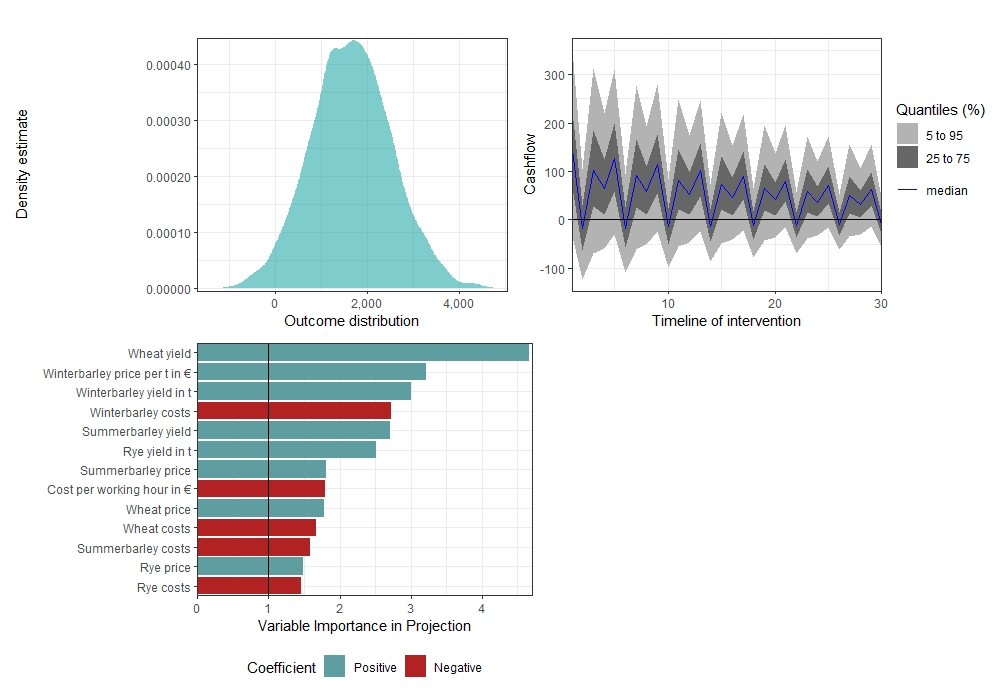

Result Baseline after 10.000 model runs, From top left to bottom right: Income Distribution accumulated values after 30 years; Annual cashflow with confidence interval; PLS analysis; EVPI analysis

The Baseline is the system that is currently run at the area of interest. In this case it is a conventional field with a crop rotation of wheat, winterbarley, summerbarley and rye. Since the field is just half a hectare big and of bad soil qualities, the accumulated income distribution over 30 years is comparable small. The Cashflow plot reveals that at least one part of the crop rotation, the rye, produces negative annual incomes in its median. The PLS analysis, plotted on the bottom left, shows that all parts of the crop rotation are important for the output. The differences are due to different yields, prices and costs for the crops. No input factors with a positive EVPI were found, so the bottom right stays blank. This baseline is the reference for all the simulated scenarios. The scenarios have to have a higher outcome distribution than the baseline. In order to test this, the outcome distribution of the baseline was subtracted from the outcome distribution of the scenarios. In the following plots for the scenarios is therefor the difference between baseline and scenario plotted. An overview where the outcome distribution for all five scenarios are plotted together is shown in the chapter “Conclusions.”

### Results Scenario 1

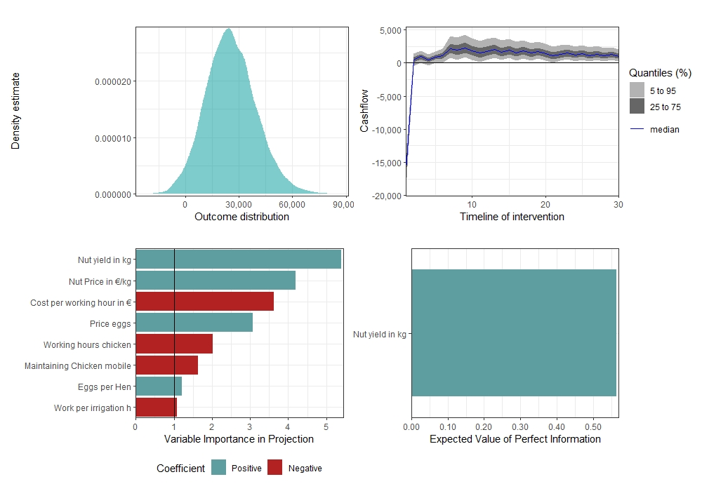

Result Scenario 1 after 10.000 model runs, From top left to bottom right: Income Distribution accumulated values after 30 years; Annual cashflow with confidence interval; PLS analysis; EVPI analysis

Scenario 1 has the narrowest distribution curve of all scenarios and in the median also the lowest simulated income. Because it uses only 70 hazelnut trees the yield uncertainty is lower than in the bigger plantations with 200 hazelnut trees. And while there is an additional income source, the hay production, this produces such small incomes that it does not widen the distribution curve. Even so the median is the lowest, because of its narrow distribution it still has mostly a positive difference compared to the baseline. Therefor it is a valid option to choose from when the goal is to improve the income of this piece of land. Additionally it is the system with the lowest investment costs and has comparable low required working hours. The cashflow plot shows the typical form for perennials. In the first year high investment costs occur. These are mainly the chicken mobile house and the hazelnut bushes. In the first 5 to 7 years the hazelnut bushes produce no hazelnuts yet but cause costs for irrigation and tree care. These costs are compensated by selling eggs. After about 7 years the hazelnuts start to produce yield and the income increases. Due to the discount rate the income decreases slowly over time. The simulated random late frost do not massively effect the income in this system since the eggs still play a big role next to the hazelnuts. The late frosts are barely visible in year 11 and 21. From the point where the hazelnut yield starts to increase, in the 90% confidence interval no annual losses are produced. The PLS analysis shows that the most important positive input factors are the hazelnut yield and price before the price per egg and their amount. Since its a work intensive system, the costs per working hour are the most important input factor for the costs. The amount of working hours for the chicken is also an important costs factor. But as a disclaimer: the working hours for the chicken are all grouped together, whereas for the hazelnut production they are more split up, they are together probably similar important. This is true for every scenario. The only input factor with a positive EVPI is the Nut yield. But the EVPI is very low, so it is questionable if this is of any worth for this decision.

### Results Scenario 2

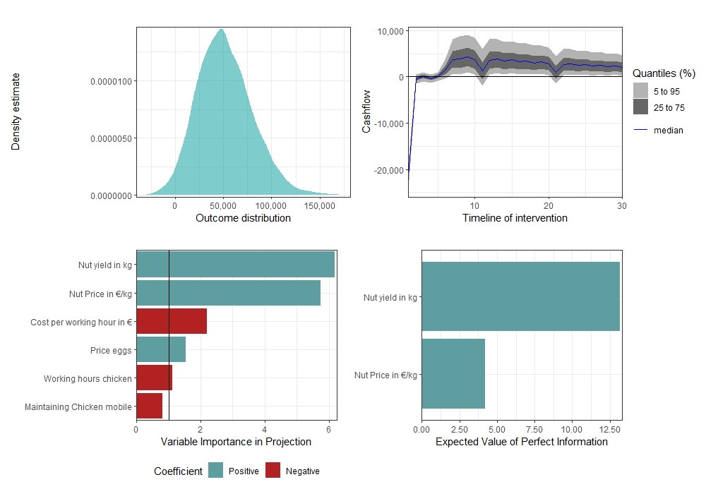

Result Scenario 2 after 10.000 model runs, From top left to bottom right: Income Distribution accumulated values after 30 years; Annual cashflow with confidence interval; PLS analysis; EVPI analysis

### Results Scenario 3

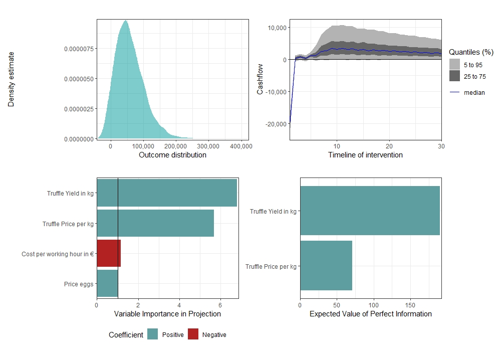

Result Scenario 3 after 10.000 model runs, From top left to bottom right: Income Distribution accumulated values after 30 years; Annual cashflow with confidence interval; PLS analysis; EVPI analysis

In scenario 3 no hazelnut bushes are planted, but instead 200 trees of different species are used to produce truffle. The outcome distribution is even wider and has a higher chance of producing losses. Next to the eggs the yield and price for the truffles determines the income. Since the truffle cultivation is connected with risks and high uncertainties, the distribution is very wide. This is also visible in the cashflow plot. After the investment costs small annual incomes are produced by selling the eggs until the truffles start to produce yield. At this point the 90% confidence interval gets very wide and incomes from 0 to 10.000€ can be produced annually. The PLS analysis confirms that truffle price and yield are the input factors who are mostly dominating the outcome of this scenario. The price per eggs play a much smaller role. The EVPI shows that it is worth to invest in additional knowledge about the truffles price and especially the truffle yield to decrease the uncertainty. This scenario has the lowest working hours and can be labeled as the “most extensive.” Especially because this system has the highest potential for CO2 fixation it is an interesting option to chose from.

### Results Scenario 4

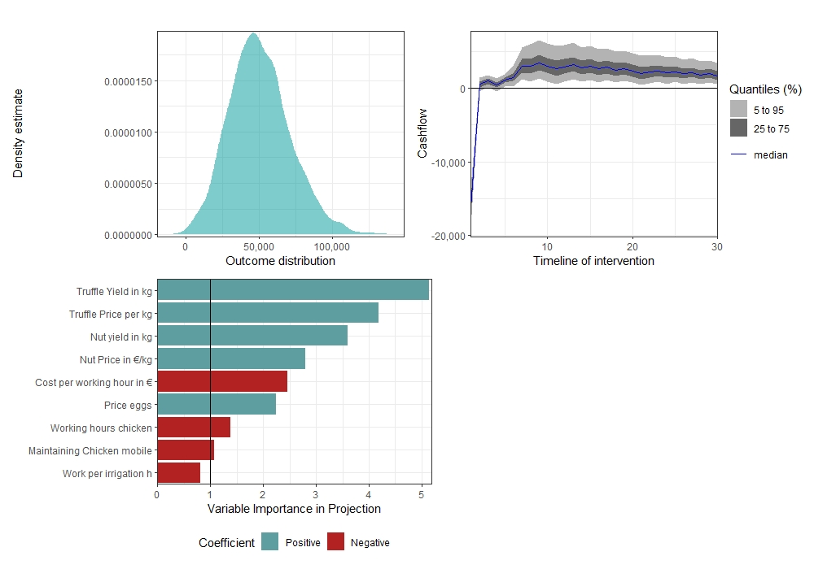

Scenario 4, which adds truffles to scenario 1, has a similar, slightly wider and overall higher, outcome distribution as scenario 1. The added truffles lead to a very low chance of producing a negative outcome and also increase the median. The cashflow plot shows slightly higher investment costs due to the need of having hazelnut saplings who are infected with truffles. The rest of the cashflow follows the same order as in scenario 1, just slightly higher. In the PLS analysis the truffle yield and price is now the most important positive input factor, before the hazelnuts and eggs. The costs per working hour remain to be the most dominant negative input factor. The EVPI analysis found no input factors with a positive VoI. If the higher initial investment costs are not a problem, scenario 4 is similar but superior to scenario 1 and will more than compensate the higher investment costs over 30 years.

### Results Scenario 5

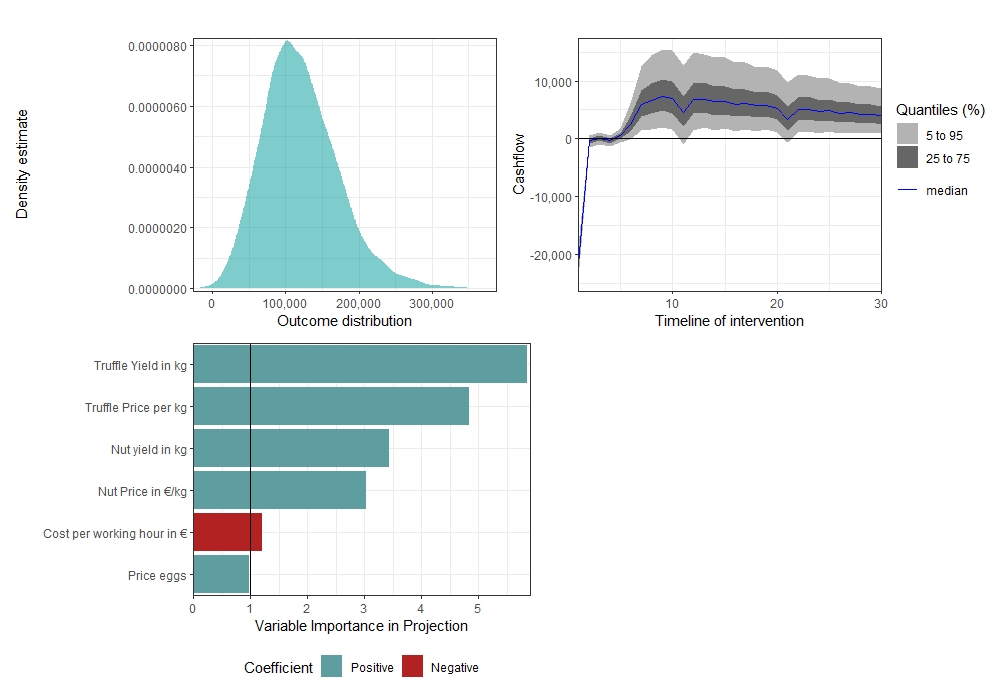

Result Scenario 5 after 10.000 model runs, From top left to bottom right: Income Distribution accumulated values after 30 years; Annual cashflow with confidence interval; PLS analysis; EVPI analysis

Scenario 5 is the same as scenario 2, just with truffles. This system has the highest median and the widest outcome distribution. The uncertainties about hazelnut and truffle yields and prices are multiplied by 200 trees. Especially the high amount of truffles increases the distribution. The cashflow shows that this system has the highest investment costs. In the first years the annual income is the same as scenario 2. The amount of eggs and the costs are the same, because the truffles only add investment costs and harvest costs, they need no additional care. But after the hazelnuts and truffles fruit, the income increases and the distribution widens. Still it is possible to experience losses in years with late frosts. The PLS analysis shows the usual ranking from truffles to hazelnuts to eggs as the most important input factors. No input factors with positive VoI where found in the EVPI analysis.

### CO2 Certificates

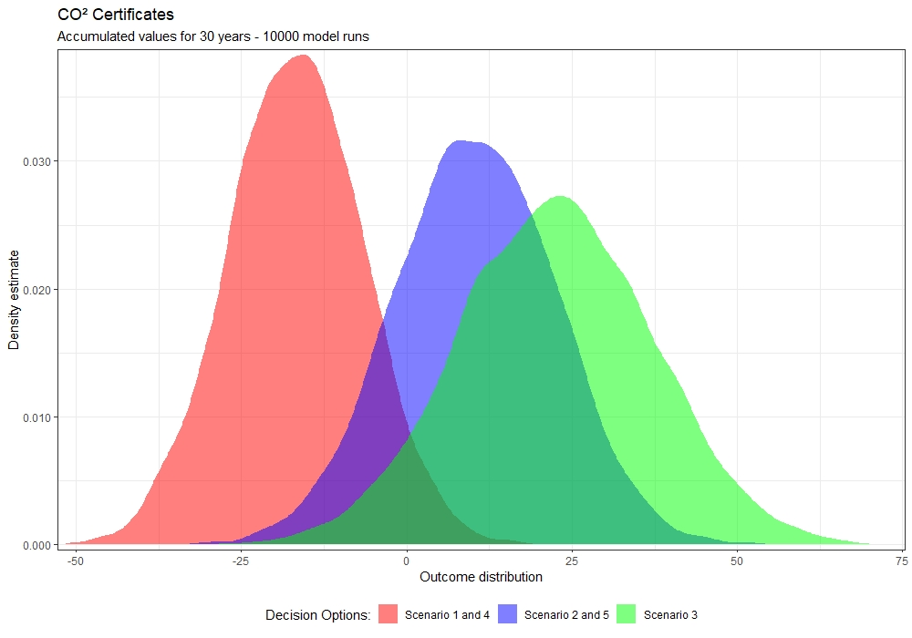

Outcome distribution of the amount of CO2 certifikates (1 certifikate = 1 ton CO2); Some scenarios are grouped as they have the same amount of trees.

The decision makers main motivation for developing an agroforestry system on this field is to have an alternative to afforestation for the sequestration of CO2. Therefor the net CO2 effect of the five scenarios where simulated. The CO2 sequestration by the trees and the landuse change are considered as well as the emissions from the egg production. The unit is CO2 certificates, one certificate is 1.000 kg CO2. This simple simulation results in positive emissions for the scenarios 1 and 4. Scenario 2 and 5, and especially scenario 3, have a good chance of having negative CO2 emissions and therefor are sequestering carbon out of the atmosphere. The differences are due to the differences between hazelnut bushes and proper trees as well as their quantity. Possible incomes from selling the certificates where not added to the simulation of the overall income of the scenarios. Notice: this simulation only includes the scenarios, not the baseline, so no decision/comparison is done. The field in its current status has most likely a stable humus content, but due to its cultivation CO2 is emitted, for example by fertilizers. So the baseline has a negative CO2 balance as well, but it is not modeled here. The reason is that the CO2 certificates should be sequestrated carbon and not avoided carbon.

## Conclusions

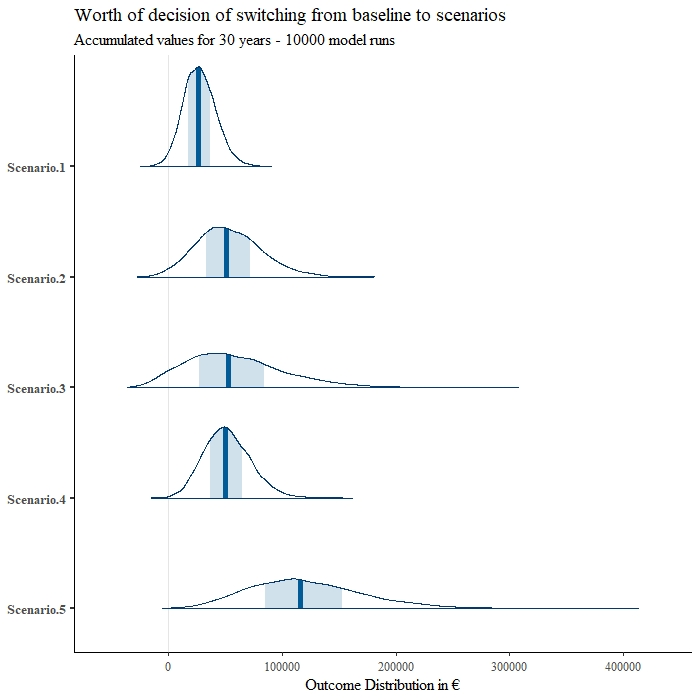

Overview of outcome distribution of decision for the five scenarios; dark blue string marks the median, light blue area the 50% confidence intervall

All scenarios are offering a bigger income compared to the baseline scenario. Based on the personal preferences of the decision maker and stakeholder the scenarios offer different advantages. They differ in investment costs, amount of working hours and sequestered carbon. They all offer not just a monetary advantage but also an ecologically improvement by adding structure, building humus and preventing erosion. Without checking the preferences of the stakeholder and improving the model, as described in the next chapter, no system is clearly superior to the other. In general the implementation of truffles makes the scenarios more profitable but also more sensitive to soil compaction. The systems with 200 trees are way more appealing when the main goal is to sequester carbon. But the income by these certificates will in every case be only a small part compared to the hazelnuts, truffles and eggs, when looking at a time period of 30 years. The main message from this simulation is, that multiple promising system exist to implement an agroforestry system even at a challenging field as this one in the Eifel. But at the same time, especially when animals are included, it can not be taken for granted that an agroforestry system as a whole system is sequestering carbon. This is why the initial plan of planning with 200 chickens was changed to 50 chickens.

### Outlook

This simulation is just an overview about the different possibilities for this piece of land. In order to make this a base for a valid business choice, the simulation has to go more in depth and also add more components to the scenarios. The after-harvest costs and risks need to be implemented to make it a holistic simulation. Disease and other risks for harvest losses should be explored. The investment in special machines should be discussed with the stakeholder, the local farmer. Also the amount and costs of working hours need to be checked with him. The amount of working hours could also be added up for each scenario, similar to the CO2 certificates, to provide an overview to help make a decision based on the personal preferences of the stakeholder. The simulation of the CO2 certificates need to be improved together with woodify. Possible restrictions for implementing perennial crops on conventional fields need to be researched. By involving more experts for hazelnuts and truffles, it may be possible to make the outcome distributions narrower, but for sure more robust. Not necessary but also interesting questions where further work could be done is that for every scenario several management options could be simulated. One example is the irrigation for scenario 3. Without the irrigation scenario 3 would have substantially lower running costs, but the risk of harvest losses is also strongly increased. If this relation is researched scenario 3 could be improved. Also the ecological benefits of each scenario can be researched.

# References

KTBL. 2021. “Leistungs-Kostenrechnung Pflanzenbau.” Edited by KTBL. https://daten.ktbl.de/dslkrpflanze/postHv.html#Ergebnis.